# Hands on Programming

Keefe Reuther

10/25/2021

## Hands On Programming

### by Garrett Grolemund

https://rstudio-education.github.io/hopr/

### Introduction

Busses are very easy to use, you just need to know which bus to get on, where to get on, and where to get off (and you need to pay your fare). Cars, on the other hand, require much more work: you need to have some type of map or directions (even if the map is in your head), you need to put gas in every now and then, you need to know the rules of the road (have some type of drivers license). The big advantage of the car is that it can take you a bunch of places that the bus does not go and it is quicker for some trips that would require transferring between busses. Using this analogy, programs like SPSS are busses, easy to use for the standard things, but very frustrating if you want to do something that is not already preprogrammed. R is a 4-wheel drive SUV (though environmentally friendly) with a bike on the back, a kayak on top, good walking and running shoes in the passenger seat, and mountain climbing and spelunking gear in the back. R can take you anywhere you want to go if you take time to learn how to use the equipment, but that is going to take longer than learning where the bus stops are in SPSS. - Greg Snow

### Project 1

You will learn to:

- Run R commands
- Create R objects
- Write your own R functions and scripts
- Load and use R packages
- Generate random samples
- Create quick plots
- Get help when you need it

```r
1+1
```

```
## [1] 2
```

```r
100:130
```

```
##  [1] 100 101 102 103 104 105 106 107 108 109 110 111 112 113 114 115 116 117 118
## [20] 119 120 121 122 123 124 125 126 127 128 129 130
```

```r
5 -
  +1
```

```
## [1] 4
```

```r
237+2
```

```
## [1] 239
```

```r
239*3
```

```
## [1] 717
```

```r
717-6
```

```
## [1] 711
```

```r
711/3
```

```
## [1] 237
```

```r
1:6
```

```
## [1] 1 2 3 4 5 6
```

```r
a <- 1
a
```

```
## [1] 1
```

```r
a*3
```

```
## [1] 3
```

```r
a^0
```

```
## [1] 1
```

```r
round(3.14, digits=1)
```

```
## [1] 3.1
```

```r
factorial(7)
```

```
## [1] 5040
```

### Including Plots

```r
die <- 1:6
die
```

```
## [1] 1 2 3 4 5 6
```

```r
ls()
```

```
## [1] "a"   "die"
```

```r
die - 1
```

```
## [1] 0 1 2 3 4 5
```

```r
die / 2
```

```
## [1] 0.5 1.0 1.5 2.0 2.5 3.0
```

```r
die * die
```

```
## [1]  1  4  9 16 25 36
```

```r
die %*% die
```

```
##      [,1]
## [1,]   91
```

```r
die %o% die
```

```
##      [,1] [,2] [,3] [,4] [,5] [,6]
## [1,]    1    2    3    4    5    6
## [2,]    2    4    6    8   10   12
## [3,]    3    6    9   12   15   18
## [4,]    4    8   12   16   20   24
## [5,]    5   10   15   20   25   30
## [6,]    6   12   18   24   30   36
```

```r
mean(die)
```

```
## [1] 3.5
```

```r
sample(die, 10, replace = TRUE)
```

```
##  [1] 1 1 4 1 1 5 1 2 5 5
```

```r
args(sample)
```

```
## function (x, size, replace = FALSE, prob = NULL)
## NULL
```

```r
dice <-  sample(die, 10, replace = TRUE)
dice
```

```
##  [1] 3 2 2 3 5 2 3 1 5 2
```

```r
sum(dice)
```

```
## [1] 28
```

### Making your own functions

```r
my_function <- function() {
  die <- 1:6
  dice <- sample(die, size = 2, replace = TRUE)
  sum(dice)
}
my_function()
```

```
## [1] 11
```

```r
my_function()
```

```
## [1] 8
```

```r
roll <- my_function()
roll
```

```
## [1] 7
```

```r
roll
```

```
## [1] 7
```

```r
roll
```

```
## [1] 7
```

```r
my_function()
```

```
## [1] 8
```

```r
roll2 <- function(bones) {
  dice <- sample(bones, size = 2, replace = TRUE)
  sum(dice)
}
roll2(bones = 1:100)
```

```
## [1] 122
```

```r
roll2 <- function(bones = 1:6) {
  dice <- sample(bones, size = 2, replace = TRUE)
  sum(dice)
}
roll2
```

```
## function(bones = 1:6) {
##   dice <- sample(bones, size = 2, replace = TRUE)
##   sum(dice)
## }
```

```r
roll2()
```

```
## [1] 10
```

### Making plots and getting packages

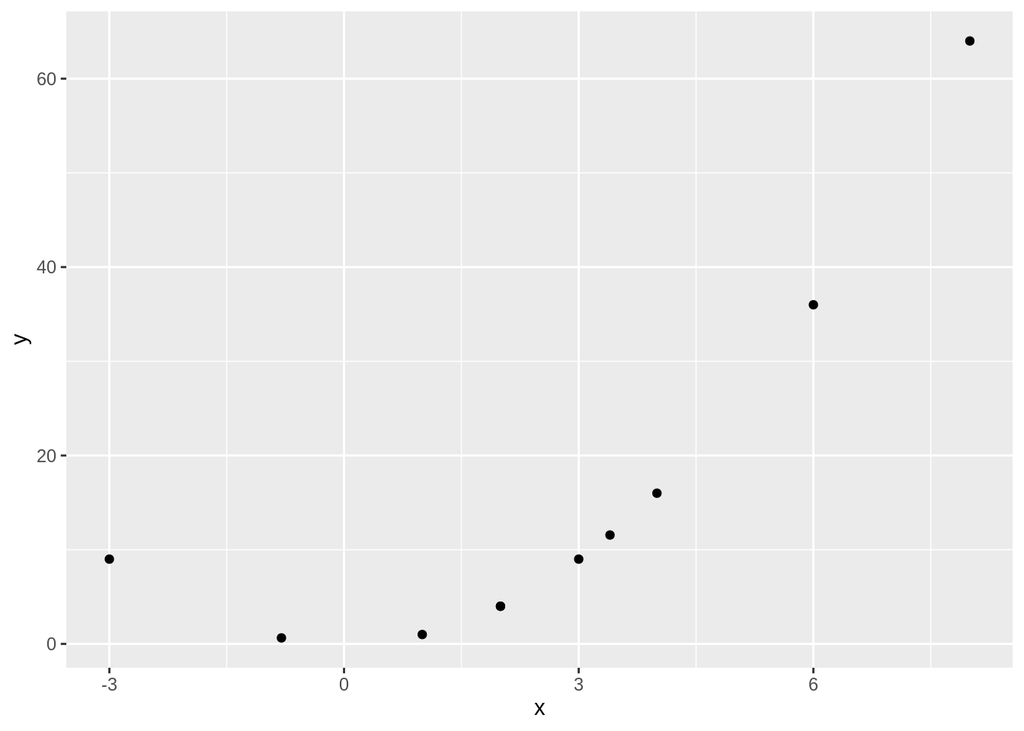

```r
library("ggplot2")
x <- c(1, 2, 3.4, -0.8, 2, -3, 3, 4, 6, 8)
y <- x^2
qplot(x, y)
```

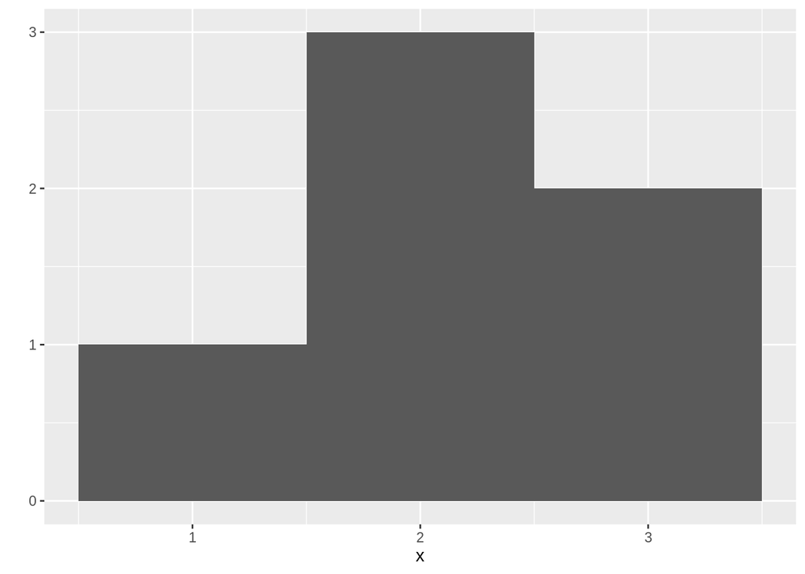

```r
x <- c(1, 2, 2, 2, 3, 3)
qplot(x, binwidth = 1)
```

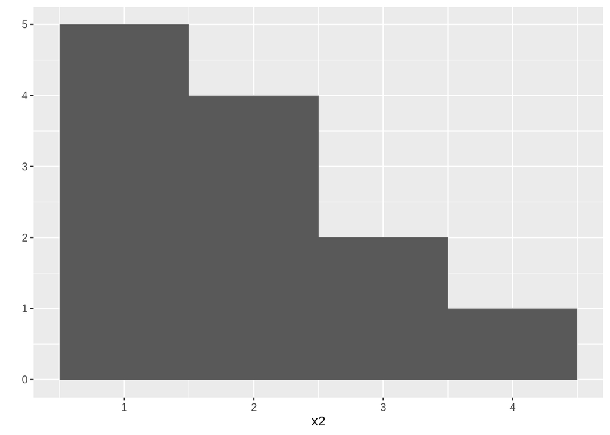

```r
x2 <- c(1,1,1,1,1,2,2,2,2,3,3,4)
qplot(x2, binwidth = 1)
```

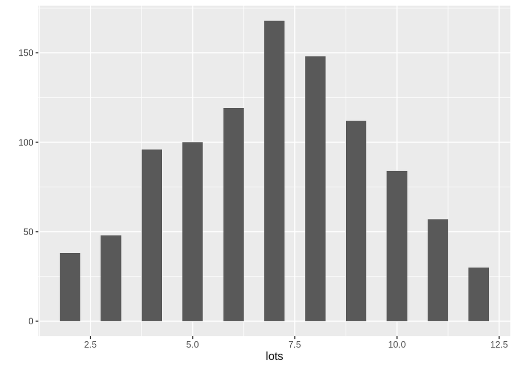

```r
lots <- replicate(1000,my_function() )
qplot(lots, binwidth = 0.5)
```

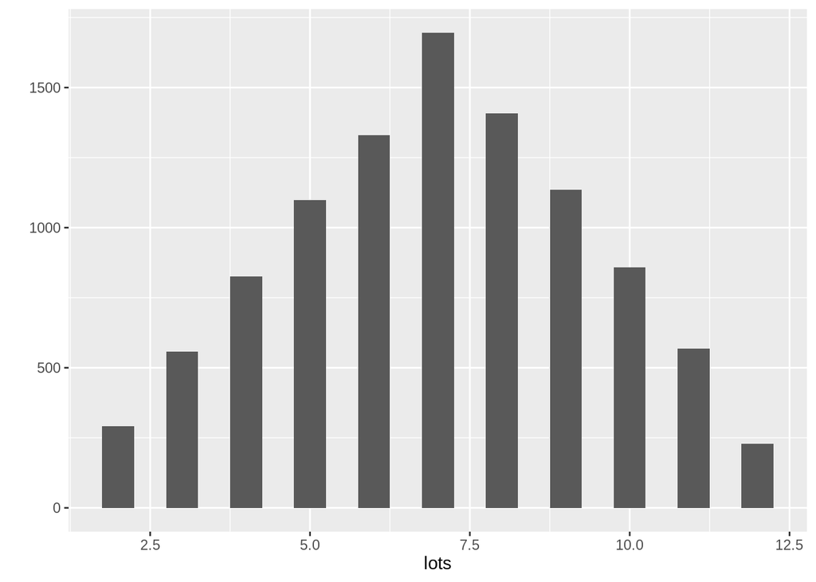

```r
?sample
lots <- replicate(10000,my_function() )
qplot(lots, binwidth = 0.5)
```

Create a function where the die roll is unevenly weighted to roll a six 50% of the time.

```r
my_function
```

```
## function() {
##   die <- 1:6
##   dice <- sample(die, size = 2, replace = TRUE)
##   sum(dice)
## }
## <bytecode: 0x5619a3c09a60>
```

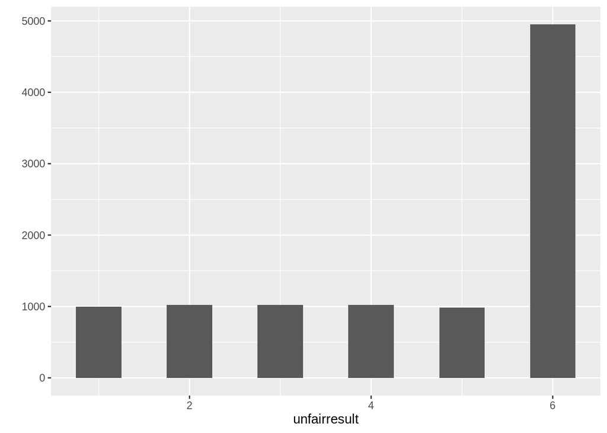

```r
unfair_dice <- function() {
  die <- 1:6
  unfair <- sample(die, size = 1, replace = TRUE, prob = c(1,1,1,1,1,5))
}
unfairresult <- replicate(10000, unfair_dice())
qplot(unfairresult, binwidth = 0.5)
```

This is the end of part 1 of *Hands on Programming*